# Rstudio Table Contest

↑+87

[figure not shown]

**Dark** (2017)

Crime  
Drama  
Mystery

8.7

258,509

3 seasons  
26 episodes

S03E08

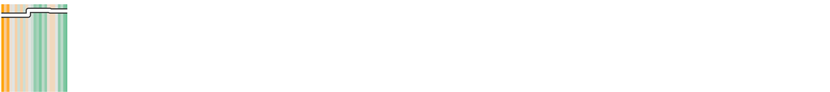

62

↓-12

[figure not shown]

**Freaks & Geeks** (1999)

Comedy  
Drama

8.7

126,679

1 season  
18 episodes

S01E16  
S01E18

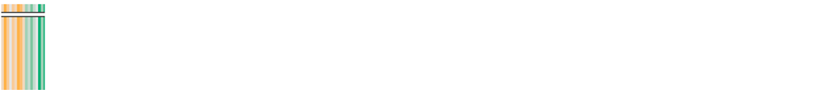

63

↑+11

[figure not shown]

**Chappelle’s Show** (2003)

Comedy  
Music

8.7

52,301

3 seasons  
33 episodes

S02E04

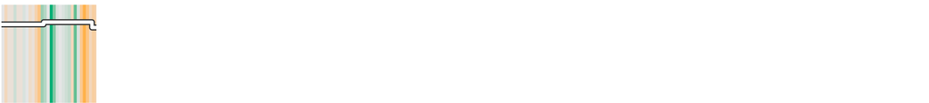

64

↓-9

[figure not shown]

**Fawlty Towers** (1975)

Comedy

8.7

83,313

2 seasons  
12 episodes

S01E06  
S02E01

[figure not shown]

65

NEW!

[figure not shown]

**Kota Factory** (2019)

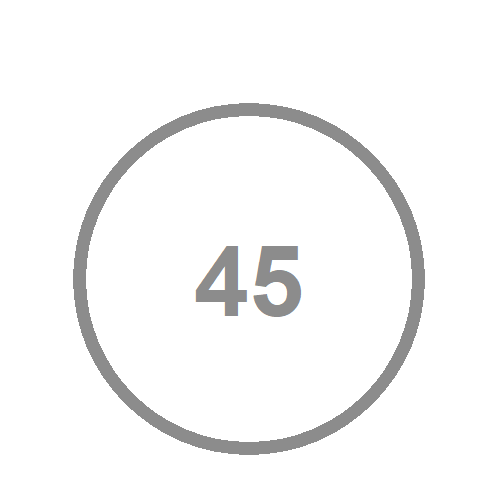

Comedy  
Drama

8.7

23,667

1 season  
5 episodes

S01E05

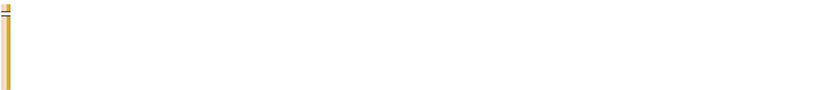

66

↓-3

[figure not shown]

**It’s Always Sunny in Philadelphia** (2005)

Comedy

8.7

186,112

14 seasons  
153 episodes

S10E04

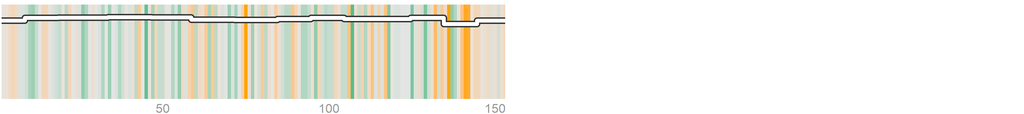

67

↑+13

[figure not shown]

**Dragon Ball Z** (1989)  
(Dragon Ball Z: Doragon bôru zetto)

Action  
Adventure  
Animation

8.7

66,300

1 season  
291 episodes

S01E237

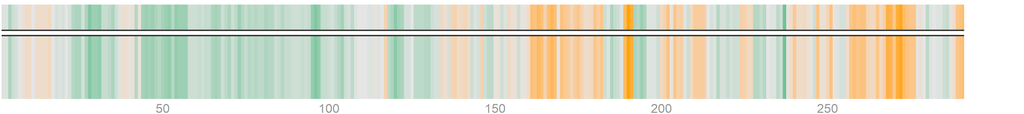

68

↓-25

[figure not shown]

**Stranger Things** (2016)

Drama  
Fantasy  
Horror

8.7

777,692

3 seasons  
25 episodes

S01E08  
S02E09

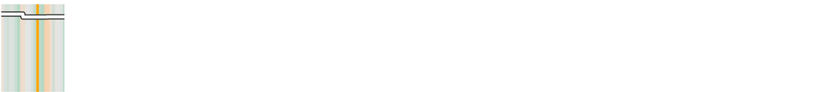

69

↓-7

[figure not shown]

**Rome** (2005)

Action  
Drama  
History

8.7

151,920

2 seasons  
22 episodes

S01E12

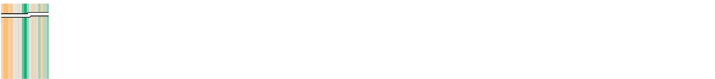

70

↓-3

[figure not shown]

**The West Wing** (1999)

Drama

8.7

61,582

7 seasons  
155 episodes

S02E22

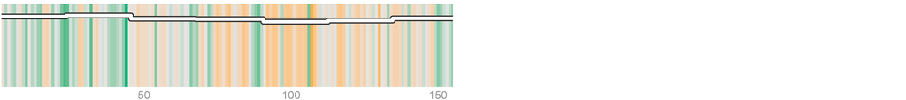

71

↓-26

[figure not shown]

**Arrested Development** (2003)

Comedy

8.7

272,271

5 seasons  
84 episodes

S03E13

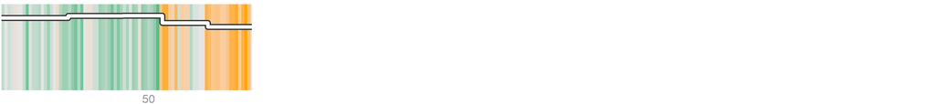

72

↑+9

[figure not shown]

**Steins;Gate** (2011)

Animation  
Comedy  
Drama

8.7

41,419

1 season  
25 episodes

S01E22  
S01E24

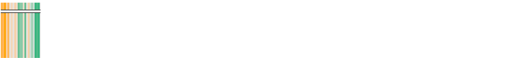

73

↑+4

[figure not shown]

**Dragon Ball Z** (1996)

Action  
Adventure  
Animation

8.7

110,341

16 seasons  
276 episodes

S14E06

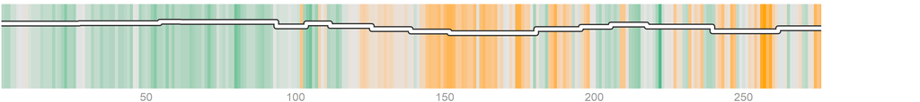

74

↑+58

[figure not shown]

**Leyla & Mecnun** (2011)  
(Leyla ile Mecnun)

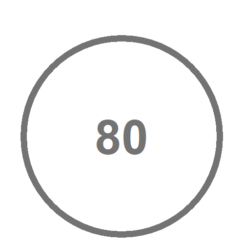

Adventure  
Comedy  
Drama

8.7

87,115

3 seasons  
104 episodes

S03E42

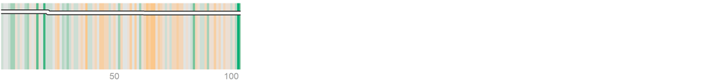

75

↑+9

[figure not shown]

**Better Call Saul** (2015)

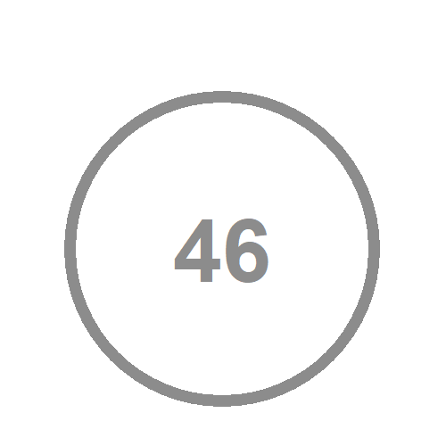

Crime  
Drama

8.7

309,089

5 seasons  
50 episodes

S05E09

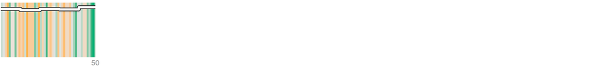

76

↓-12

[figure not shown]

**Oz** (1997)

Crime  
Drama  
Thriller

8.7

87,252

6 seasons  
56 episodes

S01E08

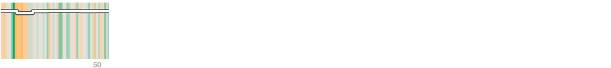

77

NEW!

[figure not shown]

**The Boys** (2019)

Action  
Comedy  
Crime

8.7

198,280

2 seasons  
16 episodes

S02E08

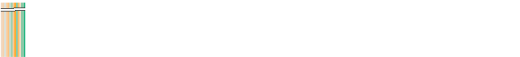

78

NEW!

[figure not shown]

**Senke nad Balkanom** (2017)

Crime  
Drama  
Thriller

8.7

8,719

2 seasons  
20 episodes

S01E07

[figure not shown]

79

↓-10

[figure not shown]

**Curb Your Enthusiasm** (2000)

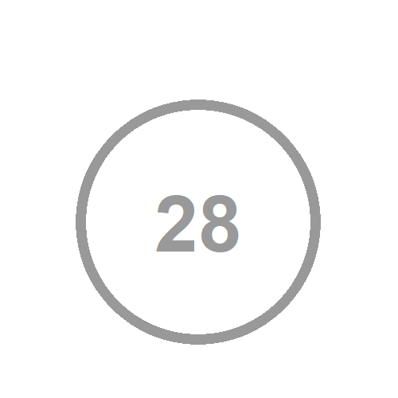

Comedy

8.7

99,624

10 seasons  
100 episodes

S02E07

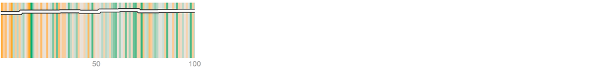

80

↓-36

[figure not shown]

**Mahabharat** (1988)

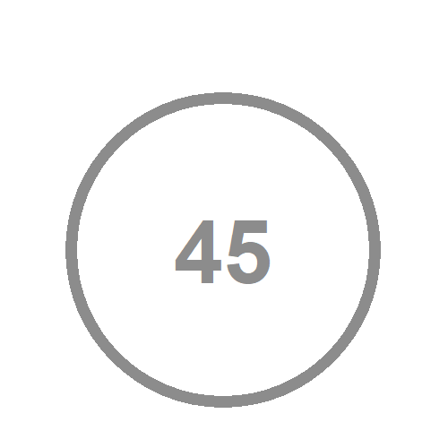

Adventure  
Drama  
History